# Practical Machine Learning Course Project

### Variable Importance

To help understand which variables have the most predictive power, the variable importance is examined. The figure below shows the scaled variable importance values for the top 20 predictors. The variable with by far the most predictive power is $roll\_belt$. Interestingly, of the top 20 variables, eight were measured on the belt, seven were measured on the dumbbell, four were measured on the forearm, and only one was measured on the arm.

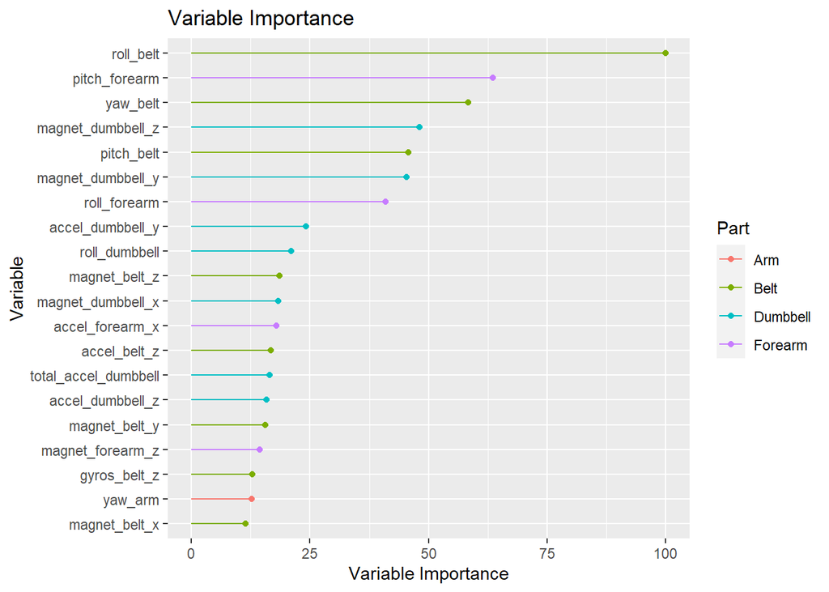

```r
imp <- varImp(fullRF)$importance
imp$movement[6:57] <-  aovresults2$movement
imp$movement[1:5] <- "Name"
imp$part[6:57] <- aovresults2$part
imp$part[1:5] <- "Name"
imp$varnames <- rownames(imp)
imp <- imp %>% arrange(desc(Overall)) %>% slice(1:20)
g <- ggplot(imp, aes(x=reorder(varnames, Overall),
                     y=Overall, color=as.factor(part)))
g + geom_point() +
      geom_segment(aes(x=varnames, xend=varnames, y=0, yend=Overall)) +
      labs(y="Variable Importance", x="Variable", title="Variable Importance") +
      scale_color_discrete(name="Part") +
      coord_flip()
```

## Precictions on the Test Set

Using the full **Random Forest** model, the Test set of 20 cases are predicted as follows.

```r
pred <- predict(fullRF, Testing)
print(pred)
```

```
##  [1] B A B A A E D B A A B C B A E E A B B B
## Levels: A B C D E
```

## Appendix

### Table A1: Analysis of Variance Results for Each Variable

```r
aovresults2[,1:3] %>%
      kbl(col.names=c("Variable", "p-value", "Cohen's f<br/>90% CI"),
          escape=FALSE) %>%
      kable_styling(full_width=FALSE) %>%
      add_footnote(c("* p-value < 0.001", "** Cohen's f 90% CI Lower Bound > 0.1"),
                   notation="none")
```

| Variable | p-value | Cohen’s f 90% CI |
| --- | --- | --- |
| roll_belt | 0.000 * | (0.07,0.10) |
| pitch_belt | 0.000 * | (0.03,0.06) |
| yaw_belt | 0.000 * | (0.03,0.06) |
| total_accel_belt | 0.000 * | (0.07,0.10) |
| gyros_belt_x | 0.000 * | (0.03,0.06) |
| gyros_belt_y | 0.004 | (0.01,0.04) |
| gyros_belt_z | 0.006 | (0.01,0.04) |
| accel_belt_x | 0.000 * | (0.04,0.07) |
| accel_belt_y | 0.000 * | (0.04,0.07) |
| accel_belt_z | 0.000 * | (0.08,0.11) |
| magnet_belt_x | 0.000 * | (0.07,0.10) |
| magnet_belt_y | 0.000 * | (0.36,0.39) ** |
| magnet_belt_z | 0.000 * | (0.23,0.26) ** |
| roll_arm | 0.000 * | (0.14,0.17) ** |
| pitch_arm | 0.000 * | (0.19,0.24) ** |
| yaw_arm | 0.000 * | (0.08,0.11) |
| total_accel_arm | 0.000 * | (0.14,0.18) ** |
| gyros_arm_x | 0.525 | (0.00,0.02) |
| gyros_arm_y | 0.002 | (0.02,0.05) |
| gyros_arm_z | 0.455 | (0.00,0.02) |
| accel_arm_x | 0.000 * | (0.30,0.33) ** |
| accel_arm_y | 0.000 * | (0.10,0.13) ** |
| accel_arm_z | 0.000 * | (0.12,0.15) ** |
| magnet_arm_x | 0.000 * | (0.36,0.39) ** |
| magnet_arm_y | 0.000 * | (0.30,0.33) ** |
| magnet_arm_z | 0.000 * | (0.26,0.29) ** |
| roll_dumbbell | 0.000 * | (0.28,0.31) ** |
| pitch_dumbbell | 0.000 * | (0.27,0.30) ** |
| yaw_dumbbell | 0.000 * | (0.10,0.12) |
| total_accel_dumbbell | 0.000 * | (0.11,0.14) ** |
| gyros_dumbbell_x | 0.283 | (0.00,0.03) |
| gyros_dumbbell_y | 0.000 * | (0.04,0.07) |
| gyros_dumbbell_z | 0.761 | (0.00,0.02) |
| accel_dumbbell_x | 0.000 * | (0.27,0.30) ** |
| accel_dumbbell_y | 0.000 * | (0.14,0.17) ** |
| accel_dumbbell_z | 0.000 * | (0.14,0.19) ** |
| magnet_dumbbell_x | 0.000 * | (0.14,0.17) ** |
| magnet_dumbbell_y | 0.000 * | (0.10,0.12) |
| magnet_dumbbell_z | 0.000 * | (0.15,0.18) ** |
| roll_forearm | 0.000 * | (0.11,0.13) ** |
| pitch_forearm | 0.000 * | (0.46,0.49) ** |
| yaw_forearm | 0.000 * | (0.10,0.13) ** |
| total_accel_forearm | 0.000 * | (0.16,0.19) ** |
| gyros_forearm_x | 0.000 * | (0.02,0.05) |
| gyros_forearm_y | 0.503 | (0.00,0.02) |
| gyros_forearm_z | 0.648 | (0.00,0.02) |
| accel_forearm_x | 0.000 * | (0.28,0.31) ** |
| accel_forearm_y | 0.000 * | (0.12,0.15) ** |
| accel_forearm_z | 0.000 * | (0.02,0.05) |
| magnet_forearm_x | 0.000 * | (0.24,0.27) ** |
| magnet_forearm_y | 0.000 * | (0.18,0.21) ** |
| magnet_forearm_z | 0.000 * | (0.08,0.11) |

* p-value < 0.001  
** Cohen’s f 90% CI Lower Bound > 0.1

## References

Cohen, Jacob. 2013. *Statistical Power Analysis for the Behavioral Sciences*. Academic press.